# Zebrafish Classification Models

## Introduction

This notebook guides users through the analysis in comparing adult and larva clusters using a supervised classification model. This was accomplished using the xgboost algorithm, which is implemented in the script `xgboost_train.R`. This script, as well as `utilFxns.R` and `plottingFxns.R`, are avaiable in the utils folder at https://github.com/shekharlab/ZebrafishRGC.

## Preprocessing

Load libraries and objects. Additionally, format objects so all genes are uppercase.

```r
# Load libraries
library(dplyr)
library(reshape2)
library(ggplot2)
source("utils/utilFxns.R") # Some useful functions imported from sc.R
source("utils/plottingFxns.R") # Some useful plotting functions
require(xgboost)
source("utils/xgboost_train.R")
library(ggplot2)
library(Seurat)

# Read in final objects
adult <- readRDS("../Objects2020/adult_zFish_object.rds")
larva <- readRDS("../Objects2020/larva_zFish_object.rds")
mature <- readRDS("../Objects2020/mature_zFish_object.rds")
immature <- readRDS("../Objects2020/immature_zFish_object.rds")

# Change genes to uppercase
adult <- UpperCase_genes(adult, integration = TRUE)
larva <- UpperCase_genes(larva)
mature <- UpperCase_genes(mature)
immature <- UpperCase_genes(immature)
```

```r
# Load variably expressed genes
adult.markers = readRDS("../Objects2020/adult_ClusterMarkers")
larva.markers = readRDS("../Objects2020/larva_ClusterMarkers")

# Only use genes with a significance level of p < 1e-10
larva_var.genes = unique(subset(larva.markers, p_val<1e-10))
adult_var.genes = unique(subset(adult.markers, p_val<1e-10))
genes.use = intersect(toupper(adult_var.genes$gene), toupper(larva_var.genes$gene))
print(head(genes.use, 30))
```

```
##  [1] "GRIA3A"          "PCDH7B"          "MEF2CB"          "PCDH19"
##  [5] "ZFHX3"           "ADCYAP1B"        "MT-CYB"          "STMN3"
##  [9] "ATP1A3B"         "NPTX1L"          "GNG13B"          "GRM6B"
## [13] "EFHD1"           "SI:DKEY-14K9.2"  "RGS8"            "SI:DKEYP-72G9.4"
## [17] "ATP1B3A"         "ELMO1"           "NDST3"           "GABRB1"
## [21] "POU6F2"          "VSTM2B"          "SOX13"           "RGS16"
## [25] "SCRT1A"          "CDH11"           "MEF2AA"          "MAP1AB"
## [29] "PLCE1"           "BTBD6A"
```

## Mapping adult clusters to mature larva clusters

Train a classification model for mature larva clusters

```r
mature_model <- TrainModel(object = mature, training_genes = genes.use, do.scale = TRUE)
```

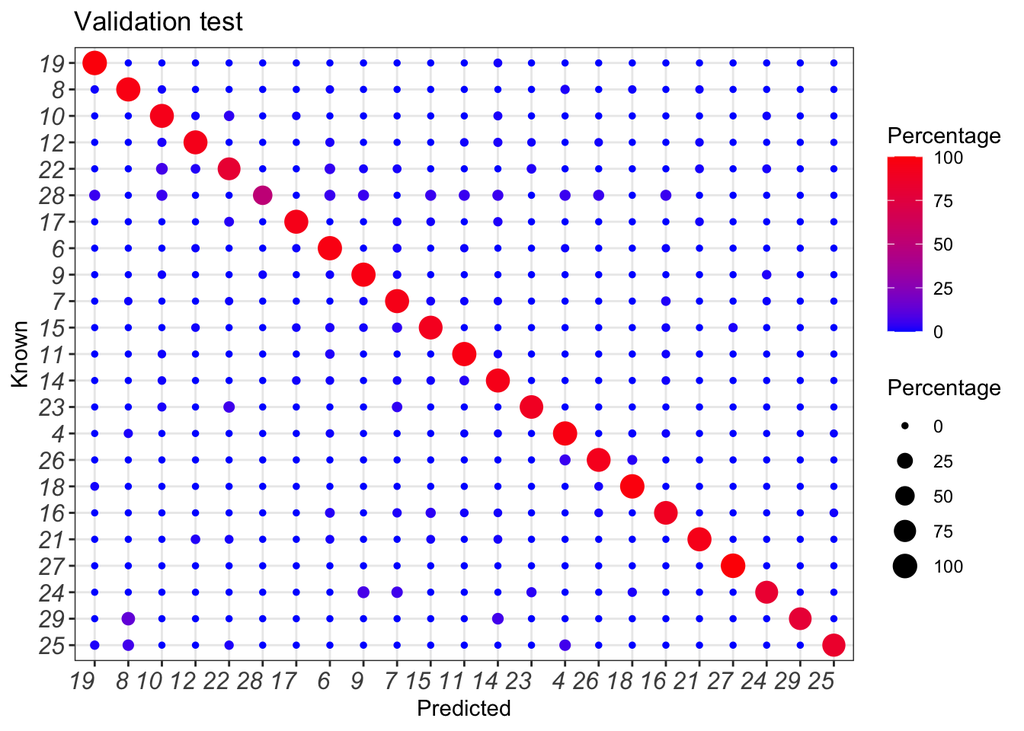

Test adult cells using the mature larva classifier and generate a confusion matrix to summarize the results.

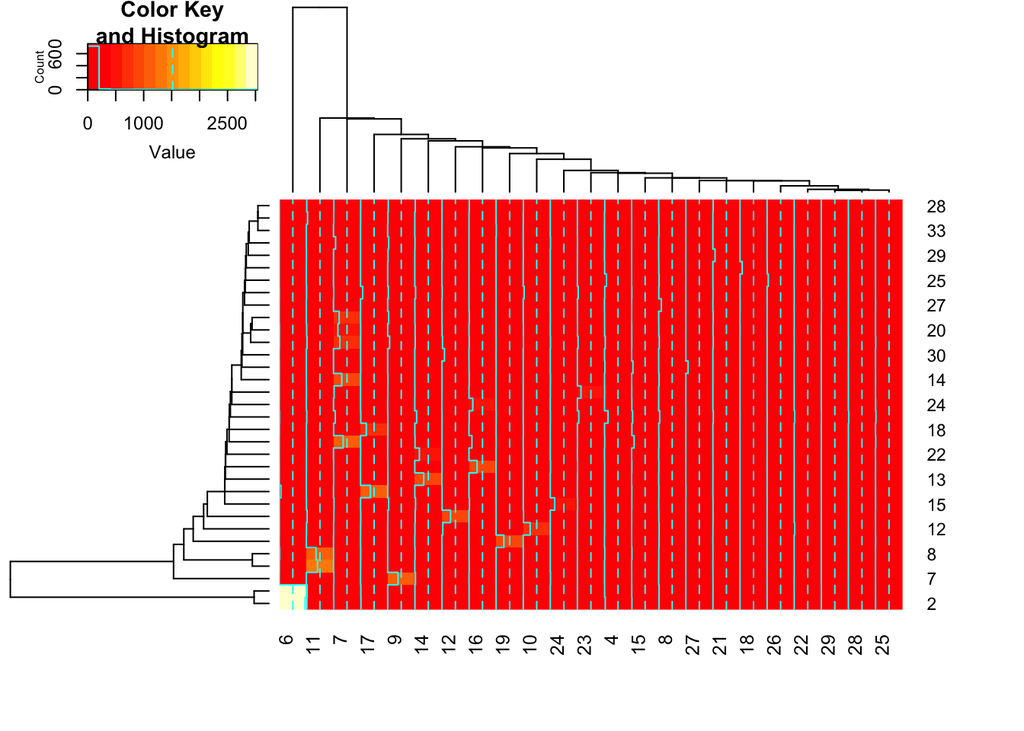

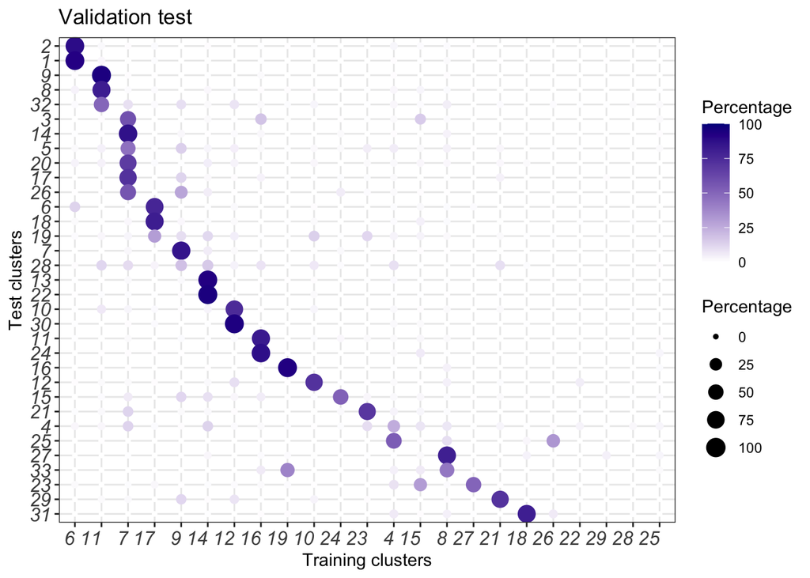

```r
adult_to_mature <- BuildConfusionMatrix(train = mature, test = adult, model = mature_model, scale.by.model = FALSE)
MakePrettyConfusionMatrix(adult_to_mature)
```

Identify one to one mappings

```r
# Create scaled row and column matrices
row_scale_mat <- adult_to_mature / rowSums(adult_to_mature)
col_scale_mat <- apply(adult_to_mature, 2, function(x) x/sum(x))

# Identify adult clusters that map strongly to a single larva cluster
# (at least 60% of the adult cluster must map to a single larva cluster)
adult_max <- which(apply(row_scale_mat, 1, max) > .6)
larva_max <- sapply(adult_max, function(x) which.max(row_scale_mat[x,]))
larva_max <- colnames(row_scale_mat)[larva_max]

# Remove mappings that aren't unique
unique_larva_max <- vector()
i <- 1
for(c in 1:length(larva_max)){
  cluster <- larva_max[c]
  remaining_clusters <- larva_max[-c]
  if(!(cluster %in% remaining_clusters)){
    unique_larva_max[i] = cluster
    i = i+1
  }
}

# Verify larval clusters map strongly to a single adult cluster
# (no more than one adult cluster accounts for 20% of the mappings to the larva cluster)
col_num_mappings <- apply(col_scale_mat, 2, function(x) sum(x>.20))
unique_larva_map <- names(which(col_num_mappings == 1))

# Identify overlap
larva_unique <- unique_larva_max[unique_larva_max %in% unique_larva_map]

# Remove larva cluster 8, as it does not seem to be one-to-one from the confusion matrix
larva_unique <- larva_unique[-which(larva_unique == "8")]

# Print final mappings
adult_unique <- names(adult_max[larva_max %in% larva_unique])
for(i in 1:length(larva_unique)){
  print(paste0("Adult cluster ", adult_unique[i], " maps to larva cluster ", larva_unique[i]))
}
```

```
## [1] "Adult cluster 7 maps to larva cluster 9"
## [1] "Adult cluster 12 maps to larva cluster 10"
## [1] "Adult cluster 16 maps to larva cluster 19"
## [1] "Adult cluster 21 maps to larva cluster 23"
## [1] "Adult cluster 29 maps to larva cluster 21"
## [1] "Adult cluster 31 maps to larva cluster 18"
```

Create a new object that only contains 1:1 matches between larva and adult

```r
# Subset data to only include one to one matches
larva_subset <- subset(larva, idents = c("9","10", "18","19", "21","23"))
larva_subset@meta.data$stage <- "larva"
larva_subset@meta.data$tag <- paste0("larva", larva_subset@meta.data$clusterID)

adult_subset <- subset(adult, idents = c("7","12", "16","21","29","31"))
adult_subset@meta.data$stage <- "adult"
adult_subset@meta.data$tag <- paste0("adult", adult_subset@meta.data$clusterID)

allFish <- merge(larva_subset, y = adult_subset, project = "zFish")
Idents(allFish) <- "tag"
allFish <- NormalizeData(allFish, normalization.method = "LogNormalize", scale.factor = 10000, verbose = FALSE)
allFish <- FindVariableFeatures(allFish, selection.method = "vst", nfeatures = 2000, verbose = FALSE)
allFish <- ScaleData(allFish, verbose = FALSE)

allFish@meta.data$match_num <- "TEST"
allFish@meta.data$match <- "TEST"
allFish@meta.data[WhichCells(allFish, idents = "adult7"),]$match_num <- "1_adult"
allFish@meta.data[WhichCells(allFish, idents = "larva9"),]$match_num <- "1_larva"
allFish@meta.data[WhichCells(allFish, idents = "adult12"),]$match_num <- "2_adult"
allFish@meta.data[WhichCells(allFish, idents = "larva10"),]$match_num <- "2_larva"
allFish@meta.data[WhichCells(allFish, idents = "adult16"),]$match_num <- "3_adult"
allFish@meta.data[WhichCells(allFish, idents = "larva19"),]$match_num <- "3_larva"
allFish@meta.data[WhichCells(allFish, idents = "adult21"),]$match_num <- "4_adult"
allFish@meta.data[WhichCells(allFish, idents = "larva23"),]$match_num <- "4_larva"
allFish@meta.data[WhichCells(allFish, idents = "adult29"),]$match_num <- "5_adult"
allFish@meta.data[WhichCells(allFish, idents = "larva21"),]$match_num <- "5_larva"
allFish@meta.data[WhichCells(allFish, idents = "adult31"),]$match_num <- "6_adult"
allFish@meta.data[WhichCells(allFish, idents = "larva18"),]$match_num <- "6_larva"
allFish@meta.data$match <- substr(allFish@meta.data$match_num, 1,1)
```

Identify pair specific markers and verify shared expression

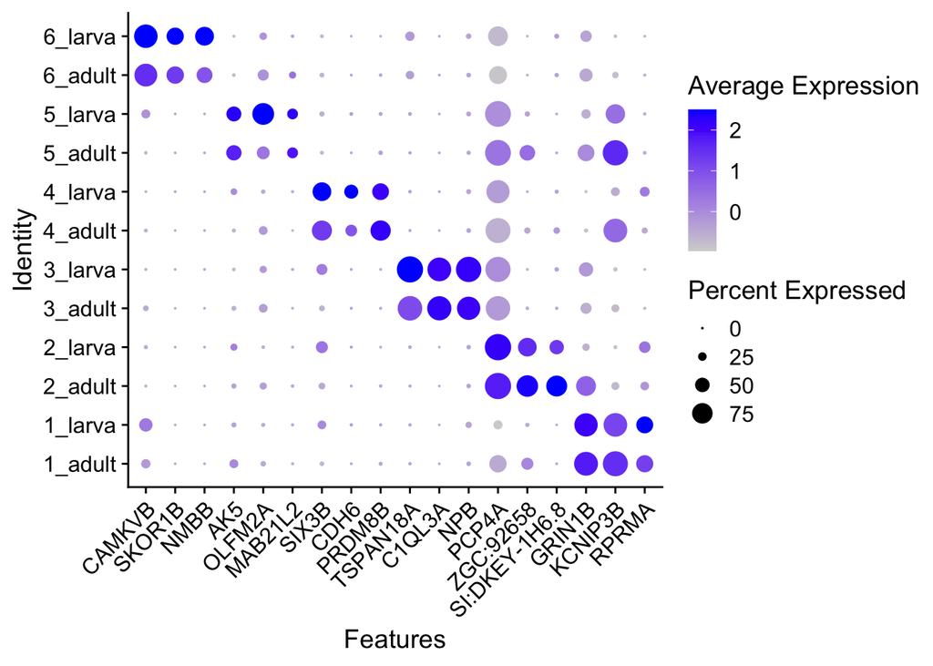

```r
# Find differentiating markers of one to one matches
Idents(allFish) <- "match"
DE_matches <- FindAllMarkers(allFish, verbose = FALSE)

# Extract the top 3 DE genes and plot them
match_genes <- vector()
for(i in 1:length(DE_matches)){
  match_genes = union(match_genes, subset(DE_matches, cluster == i)[1:3,]$gene)
}

DotPlot(allFish, features = match_genes, group.by = "match_num") + RotatedAxis()
```

Identify DE genes globally associated with maturation

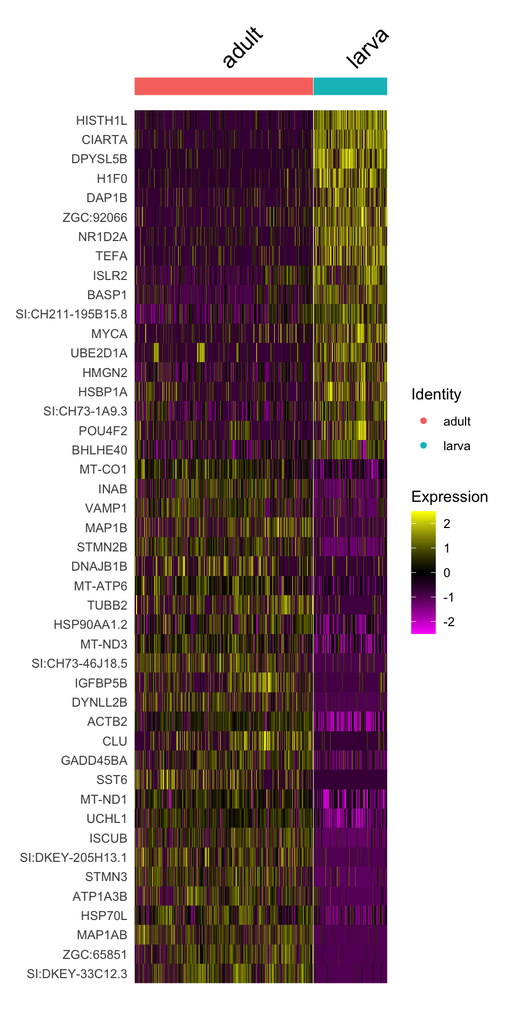

```r
# Set idents to stage and find all markers
Idents(allFish) <- "stage"
global_markers <- FindMarkers(allFish, ident.1 = "adult", ident.2="larva", max.cells.per.ident = 1000, verbose = FALSE)

# Define a gene as globally expressed if logFC > 1 and is pct1 or pct2 is greater than .5
avg_logFC_threshold <- 1
pct_threshold <- .5

global_DEgenes_mat <- global_markers[abs(global_markers[,"avg_logFC"]) > avg_logFC_threshold,]
global_DEgenes <- rownames(global_DEgenes_mat[(global_DEgenes_mat[,"pct.1"] > pct_threshold) | (global_DEgenes_mat[,"pct.2"] > pct_threshold), ])

# Sort genes based on order of avg_logFC
global_DEgenes_mat <- global_DEgenes_mat[global_DEgenes,]
gene_order <- sort(global_DEgenes_mat$avg_logFC, index.return = TRUE)$ix
global_DEgenes <- global_DEgenes[gene_order]

# Generate a heat map showing differences in gene expression
DoHeatmap(object = allFish, features = global_DEgenes, group.by = "stage")
```

## Mapping mature larva clusters to immature larva clusters

Train a classification model for immature larva clusters

```r
immature_model <- TrainModel(object = immature, training_genes = genes.use, do.scale = TRUE)
```

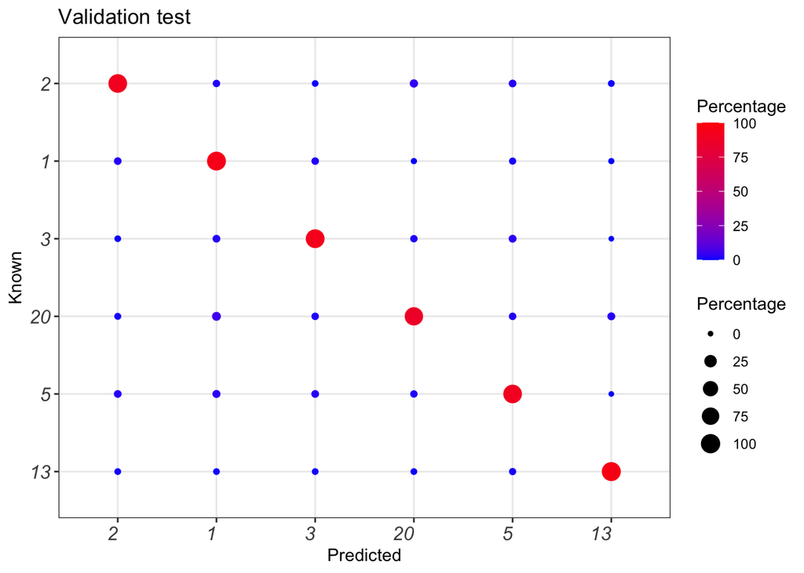

Test mature larva cells using the immature larva classifier and generate a confusion matrix to summarize the results.

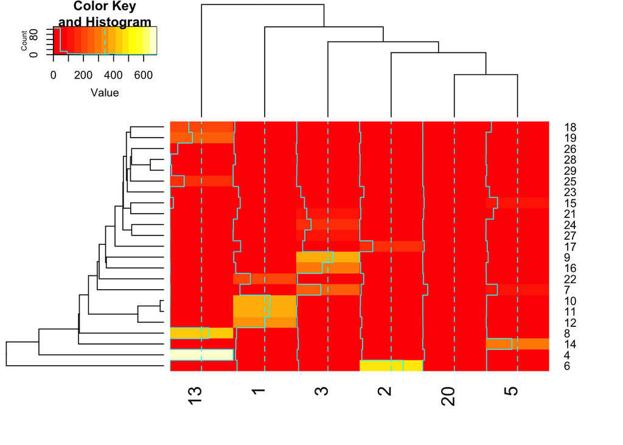

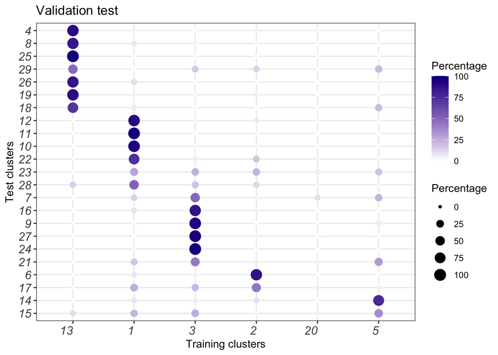

```r
mature_to_immature <- BuildConfusionMatrix(train = immature, test = mature, model = immature_model, scale.by.model = FALSE)
MakePrettyConfusionMatrix(mature_to_immature)
```